# Анализ выживаемости пациентов

09/03/2021

### Необходимые библиотеки в R:

```r
require(ggplot2)
require(survival)
require(ggfortify)
require(survminer)
require(ranger)
require(coin)
```

### Подготовка данных:

```r
df <- ovarian
str(df)
```

```
## 'data.frame':    26 obs. of  6 variables:
##  $ futime  : num  59 115 156 421 431 448 464 475 477 563 ...
##  $ fustat  : num  1 1 1 0 1 0 1 1 0 1 ...
##  $ age     : num  72.3 74.5 66.5 53.4 50.3 ...
##  $ resid.ds: num  2 2 2 2 2 1 2 2 2 1 ...
##  $ rx      : num  1 1 1 2 1 1 2 2 1 2 ...
##  $ ecog.ps : num  1 1 2 1 1 2 2 2 1 2 ...
```

```r
df$resid.ds <- factor(df$resid.ds, levels = c('1', '2'), labels = c("No", "Yes"))
df$rx <- as.factor(df$rx)
df$ecog.ps <- factor(df$ecog.ps, levels = c('1', '2'), labels = c('Good', 'Not good') )
str(df)
```

```
## 'data.frame':    26 obs. of  6 variables:
##  $ futime  : num  59 115 156 421 431 448 464 475 477 563 ...
##  $ fustat  : num  1 1 1 0 1 0 1 1 0 1 ...
##  $ age     : num  72.3 74.5 66.5 53.4 50.3 ...
##  $ resid.ds: Factor w/ 2 levels "No","Yes": 2 2 2 2 2 1 2 2 2 1 ...
##  $ rx      : Factor w/ 2 levels "1","2": 1 1 1 2 1 1 2 2 1 2 ...
##  $ ecog.ps : Factor w/ 2 levels "Good","Not good": 1 1 2 1 1 2 2 2 1 2 ...
```

### Проведем первичный анализ данных, построим графики и распределения:

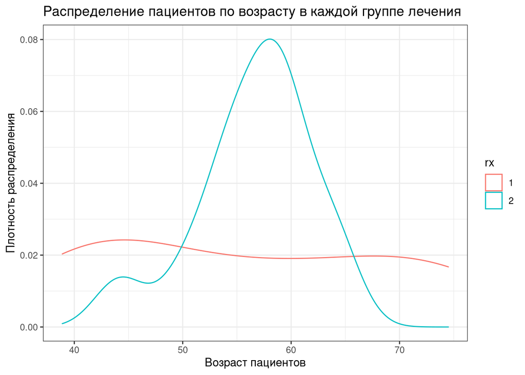

```r
library(ggplot2)
ggplot(data = df, aes(x = age, col = rx)) + geom_density() + theme_bw() + xlab("Возраст пациентов") +
  ylab("Плотность распределения") +
  ggtitle('Распределение пациентов по возрасту в каждой группе лечения')
```

Видим, что в первой группе лечения распределение по возрасту более равномерное

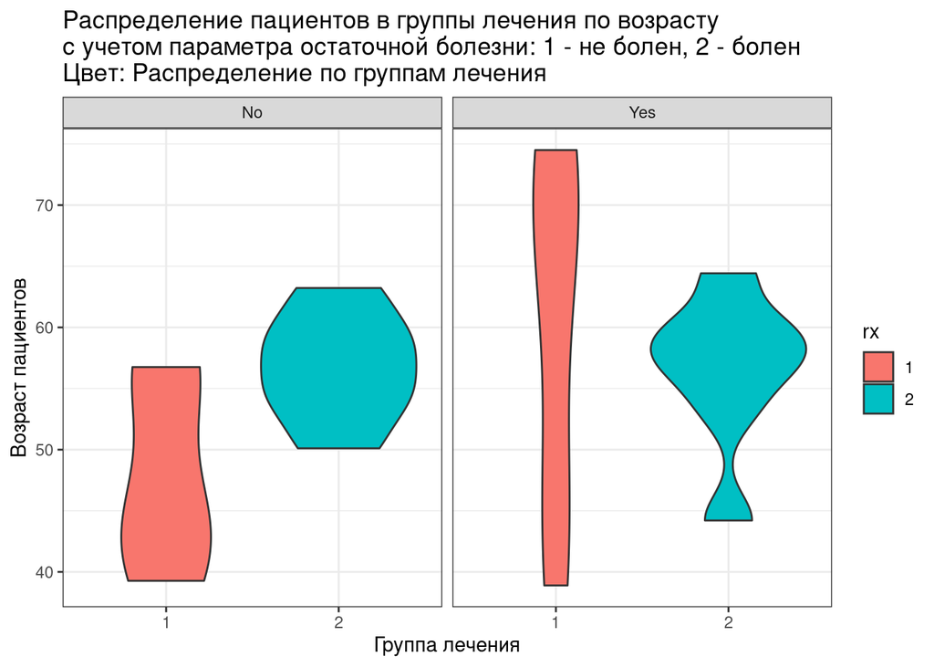

```r
ggplot(data = df, aes(x = rx, y = age, fill = rx)) +
  geom_violin() +
  theme_bw() +
  ggtitle("Распределение пациентов в группы лечения по возрасту\nс учетом параметра остаточной болезни: 1 - не болен, 2 - болен\nЦвет: Распределение по группам лечения") +
  facet_wrap(.~resid.ds)+
  ylab("Возраст пациентов") +
  xlab("Группа лечения")
```

Люди с остаточной болезнью, как правило, старше, в обеих группах лечения, однако это скорее следствие возраста (приобретение болезней с возрастом)

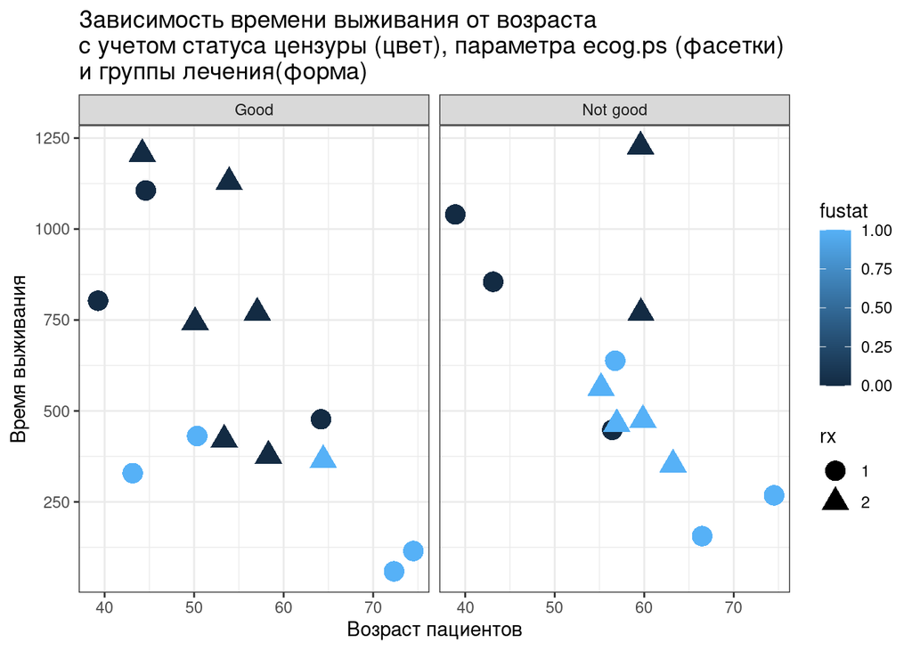

```r
ggplot(data = df, aes(x = age, y = futime, col = fustat, shape = rx)) +
  geom_point(size = 5) +
  theme_bw() +
  facet_wrap(~ecog.ps) +
  ggtitle("Зависимость времени выживания от возраста\nс учетом статуса цензуры (цвет), параметра ecog.ps (фасетки)\nи группы лечения(форма)")+
  xlab("Возраст пациентов")+
  ylab("Время выживания")
```

Видно, что у пациентов со статусом цензуры 1 время выживания меньше. Это можно объяснить смертью пациентов.

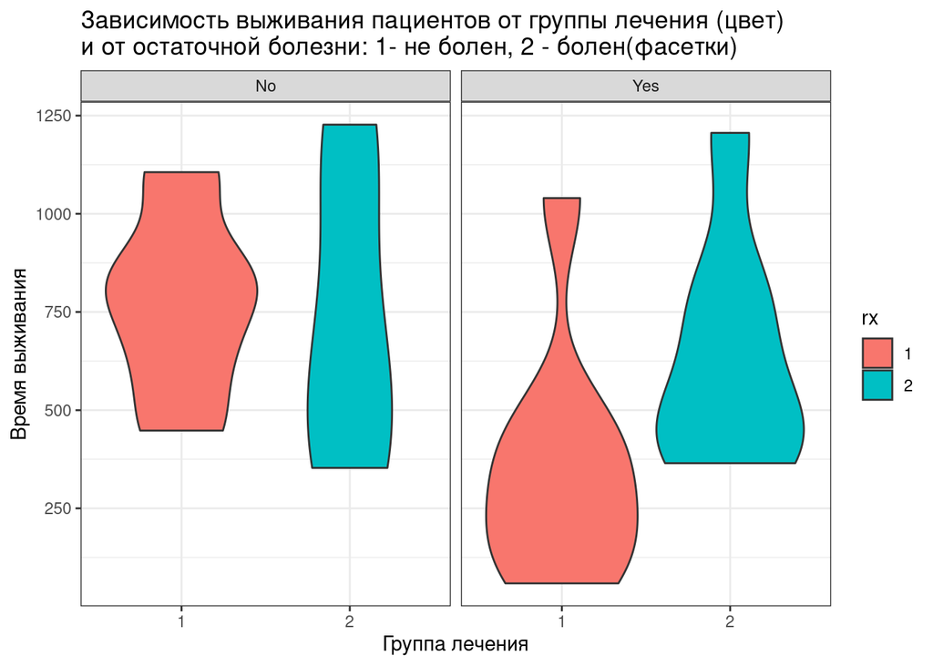

```r
ggplot(data = df, aes(x = rx, y = futime, fill = rx)) +
  geom_violin() +
  theme_bw() +
  facet_wrap(.~resid.ds)+
  ylab("Время выживания") +
  xlab("Группа лечения") +
  ggtitle("Зависимость выживания пациентов от группы лечения (цвет)\nи от остаточной болезни: 1- не болен, 2 - болен(фасетки)")
```

Отчетливо видно, что при наличии остаточной болезни, пациенты из первой группы лечения живут меньше.

### Кривые Каплана-Мейра:

Будем оценивать вероятность смерти конкретного индивидума в зависимости от времени t. Для начала создадим временной интервал, в рамках которого мы будет оценивать выживаемость, далее построим линейную модель, которая учитывает изменение в выживаемости на основании фактора (группа лечения, параметр ecog.ps, возраст, например) в зависимости от времени.

1. Простая модель:

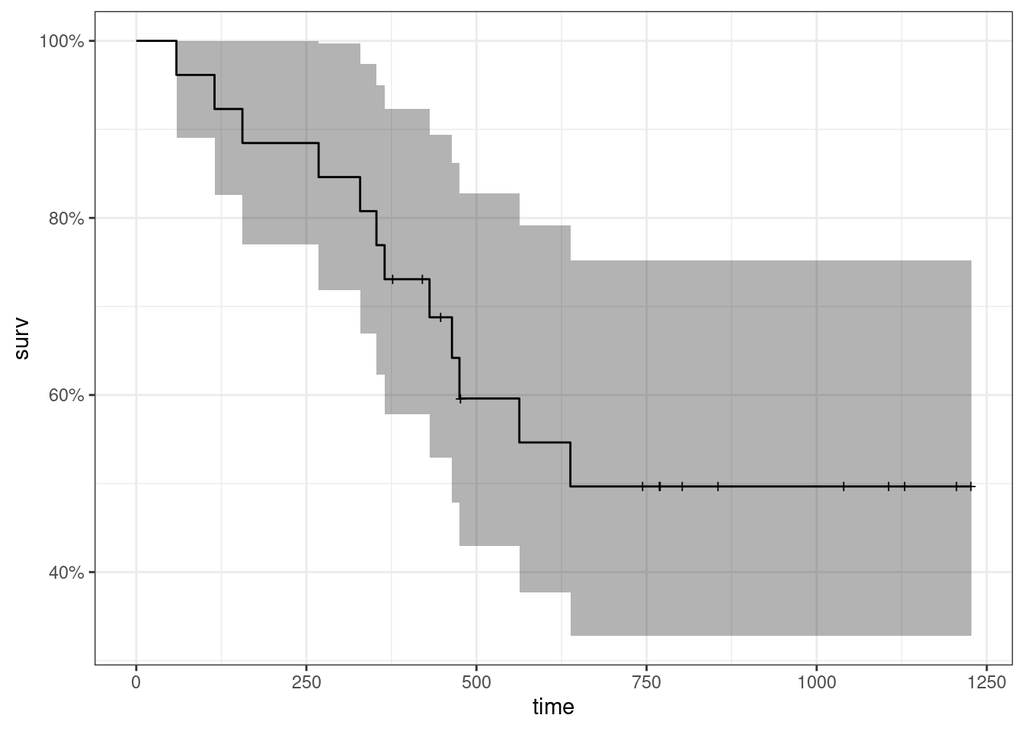

```r
km_fit <- survfit(Surv(futime, fustat) ~ 1, data=df)
autoplot(km_fit) + theme_bw()
```

2. Посмотрим кривую выживаемости в зависимости от типа лечения:

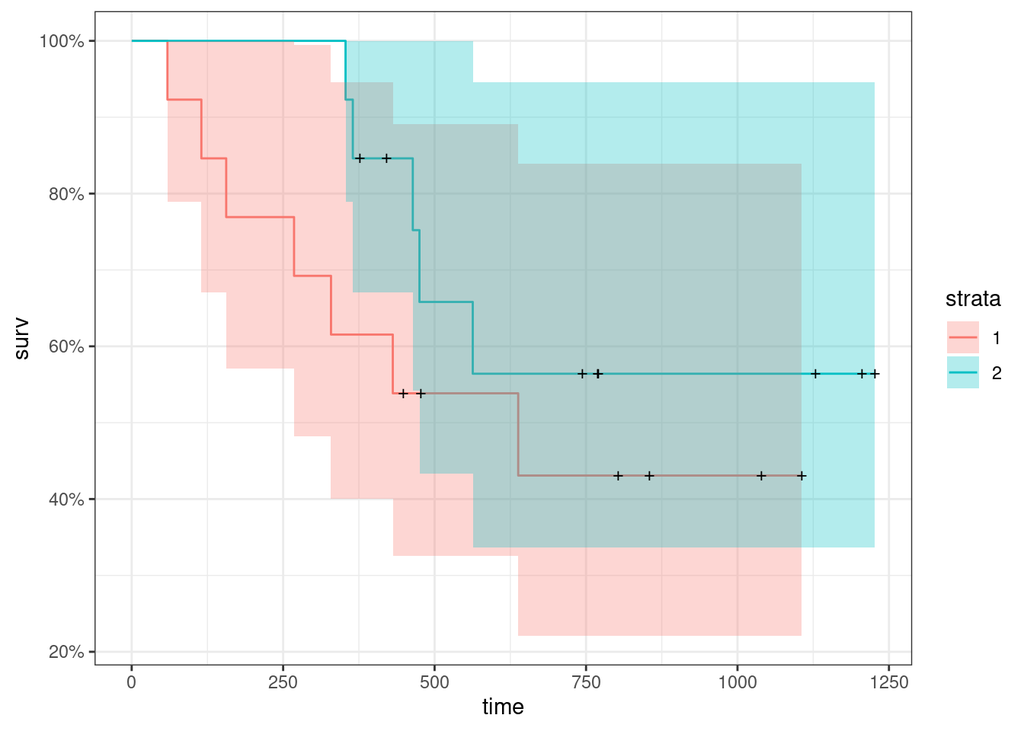

```r
km_2 <- survfit(Surv(futime, fustat) ~ rx, data=df)
autoplot(km_2) + theme_bw()
```

Кривая, соответствующая второму типу лечения, выше.

3. Посмотрим кривые в зависимости от параметра ecog.ps:

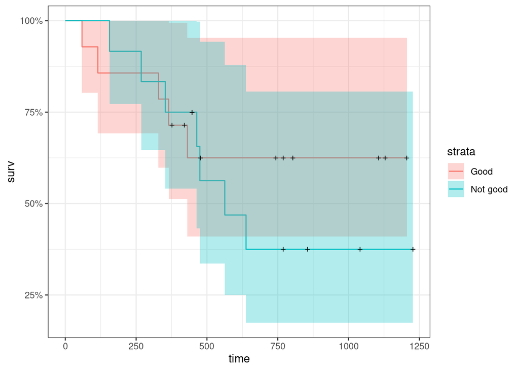

```r
km_3 <- survfit(Surv(futime, fustat) ~ ecog.ps, data=df)
autoplot(km_3) + theme_bw()
```

При длительном времени ожидания значение 1 (good) показывает лучшие результаты, хотя на малых временах ситуация неоднозначная.

4. Посмотрим выживаемость в зависимости от наличия остаточной болезни:

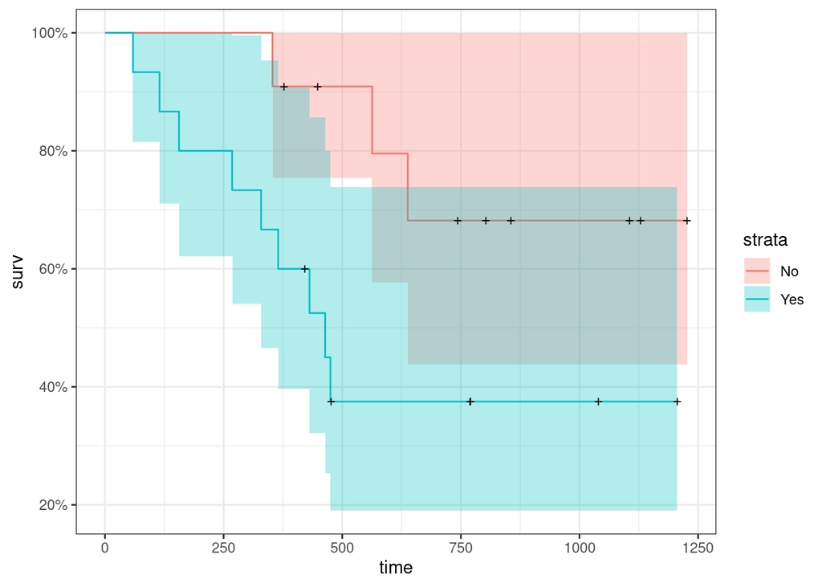

```r
km_4 <- survfit(Surv(futime, fustat) ~ resid.ds, data=df)
autoplot(km_4) + theme_bw()
```

Отчетливо видно, что люди, переносящие дополнительное заболевание, выживают хуже.

5. Наконец, проверим, одинаково ли выживают молодые и старые. Сначала разделим пациентов по возрасту с границей 55.

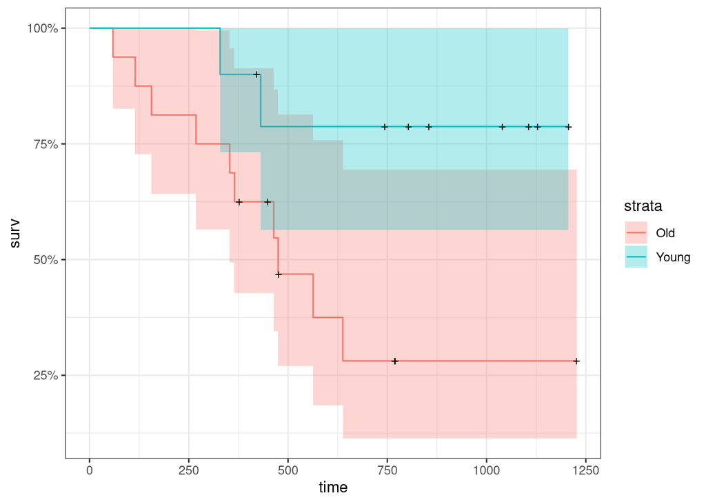

```r
df$age_factor <- factor(ifelse(df$age < 55, 'Young', 'Old'))
km_5 <- survfit(Surv(futime, fustat) ~ age_factor, data=df)
autoplot(km_5) + theme_bw()
```

Видно, что молодые показывают лучшие результаты, хотя в группе молодых больше зацензурированных значений, что, вероятно, означает выздоровление, но не точно.

### Далее необходимо оценить, какие именно группы статистически различаются по выживаемости:

Будем использовать лог-ранг тесты для сравнения выживаемости между группами.

```r
survdiff(Surv(futime, fustat) ~ rx, data = df)
```

```
## Call:
## survdiff(formula = Surv(futime, fustat) ~ rx, data = df)
##
##       N Observed Expected (O-E)^2/E (O-E)^2/V
## rx=1 13        7     5.23     0.596      1.06
## rx=2 13        5     6.77     0.461      1.06
##
##  Chisq= 1.1  on 1 degrees of freedom, p= 0.3
```

```r
survdiff(Surv(futime, fustat) ~ ecog.ps, data = df)
```

```
## Call:
## survdiff(formula = Surv(futime, fustat) ~ ecog.ps, data = df)
##
##                   N Observed Expected (O-E)^2/E (O-E)^2/V
## ecog.ps=Good     14        5     6.18     0.226     0.468
## ecog.ps=Not good 12        7     5.82     0.240     0.468
##
##  Chisq= 0.5  on 1 degrees of freedom, p= 0.5
```

```r
survdiff(Surv(futime, fustat) ~ resid.ds, data = df)
```

```
## Call:
## survdiff(formula = Surv(futime, fustat) ~ resid.ds, data = df)
##
##               N Observed Expected (O-E)^2/E (O-E)^2/V
## resid.ds=No  11        3     6.26      1.70      3.62
## resid.ds=Yes 15        9     5.74      1.85      3.62
##
##  Chisq= 3.6  on 1 degrees of freedom, p= 0.06
```

```r
survdiff(Surv(futime, fustat) ~ age_factor, data = df)
```

```
## Call:
## survdiff(formula = Surv(futime, fustat) ~ age_factor, data = df)
##
##                   N Observed Expected (O-E)^2/E (O-E)^2/V
## age_factor=Old   16       10     6.37      2.06      4.49
## age_factor=Young 10        2     5.63      2.34      4.49
##
##  Chisq= 4.5  on 1 degrees of freedom, p= 0.03
```

Значимые различия наблюдаются только в зависимости от возраста (p-value < 0.05, 1 df, Chisq= 4.5). Все остальные сравнения демонстрируют уровень значимости выше 0.05.

### Проведем анализ факторов, влияющих на риск с помощью отношения рисков и модели Кокса:

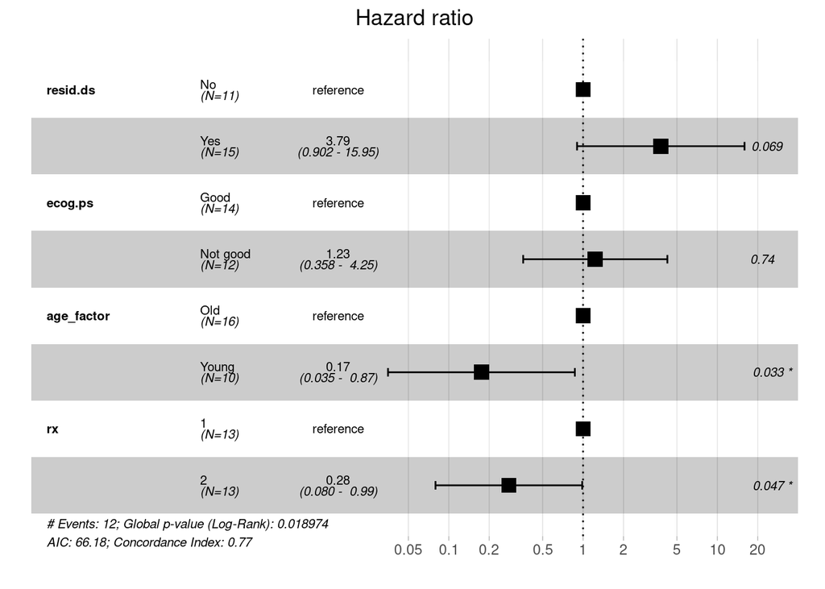

```r
fit.coxph <- coxph(Surv(futime, fustat) ~ resid.ds + ecog.ps + age_factor + rx, data = df)
ggforest(fit.coxph, data = df)
```

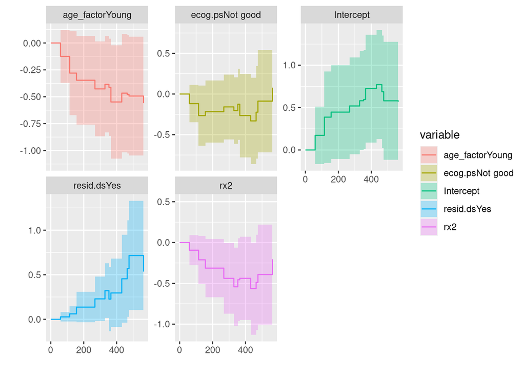

```r
aa_fit <- aareg(Surv(futime, fustat) ~ resid.ds + ecog.ps + age_factor + rx, data = df)
autoplot(aa_fit)
```

Видим, что молодой возраст снижает риски, как и второй тип лечения, наличие остаточной болезни - повышает, но не значимо, значение параметра ecog.ps “Not good” повышает, но также не значимо.